# Examen final: Avance 1

Lucio Cornejo

2025-04-21

## Descripción

Los datos fueron descargados de este sitio [web](https://www.kaggle.com/datasets/shubhamsingh57/ml-model-practice-linear-regression/data).

La investigación consiste en **predecir** el costo a pagar, considerando el descuento que proporciona el seguro médico, por algún procedimiento médico.

Estos datos son de distintos pacientes que recibieron algún tipo de tratamiento médico, de los cuales se tienen variables recopiladas, como edad, sexo, si fuma o no, etc. Así, descartamos que los datos consistan de una serie de tiempo.

En ese sentido, como objetivo de la investigación, no solo se considera la predicción de la variable mencionada, sino también cómo es que influyen las variables que emplearemos como regresores, en la predicción final. Por ejemplo, si su relación es directa o inversamente proporcional.

## Estructura de los datos

A continuación, mostramos los datos descargados del sitio web mencionado en la sección previa.

```r
library(dplyr)
library(tidyr)
library(ggplot2)
library(reshape2)
```

```r
datos <- readr::read_csv("new_insurance_data.csv")
dplyr::glimpse(datos)
```

```
## Rows: 1,338
## Columns: 13
## $ age                             <dbl> 18, 18, 18, 18, 18, 18, 18, 18, 18, 18, 19, 19, 19, 19, 19, 19, NA, 19, 19, 20, 21, ~
## $ sex                             <chr> "male", "male", "male", "male", "male", "male", "male", "male", "male", "male", "mal~
## $ bmi                             <dbl> 23.210, 30.140, 33.330, 33.660, 34.100, 34.430, 37.290, 41.140, 43.010, 53.130, 19.8~
## $ children                        <dbl> 0, 0, 0, 0, 0, 0, 0, 0, 0, 0, 0, 0, 0, 0, 0, 0, 0, 0, 0, 0, 0, 0, 0, 0, 0, 0, 0, 0, ~
## $ smoker                          <chr> "no", "no", "no", "no", "no", "no", "no", "no", "no", "no", "no", "no", "no", "no", ~
## $ Claim_Amount                    <dbl> 29087.543, 39053.674, 39023.628, 28185.393, 14697.859, 26488.339, 33217.365, 46770.5~
## $ past_consultations              <dbl> 17, 7, 19, 11, 16, 20, 13, 12, 17, 19, 2, NA, 4, 8, 3, 15, 3, 2, 2, 14, 10, 6, 15, 7~
## $ num_of_steps                    <dbl> 715428, 699157, 702341, 700250, 711584, 717162, 699159, 706423, NA, 704425, 706796, ~
## $ Hospital_expenditure            <dbl> 4720921.0, 4329831.7, 6884860.8, 4274773.5, 3787293.9, 3696160.7, 876529.2, 4486741.~
## $ Number_of_past_hospitalizations <dbl> 0, 0, 0, 0, 0, 0, 0, 0, 0, 0, 0, 0, NA, 0, 0, 0, 0, 0, 0, 0, 0, 0, 0, 0, 0, 0, 0, 0,~
## $ Anual_Salary                    <dbl> 55784970, 13700885, 73523107, 75819680, 23012320, NA, 69060666, 97193784, 58881972, ~
## $ region                          <chr> "southeast", "southeast", "southeast", "southeast", "southeast", "southeast", "south~
## $ charges                         <dbl> 1121.874, 1131.507, 1135.941, 1136.399, 1137.011, 1137.470, 1141.445, 1146.797, 1149~
```

### Variables iniciales

- Variables **cualitativas**
  - `sex`: Sexo.
  - `smoker`: Si el paciente fuma o no.
  - `region`: Región de la que provee el paciente.
- Variables **cuantitativas**
  - `age`: Edad.
  - `bmi`: Índice de masa corporal.
  - `children`: Cantidad de hijos e hijas.
  - `Claim_Amount`: Costo médico que el paciente pagaría en caso no se aplicase seguro médico.
  - `past_consultations`: Número de procedimientos pasados del paciente.
  - `num_of_steps`: Número de pasos que realizó el paciente en cierto día.
  - `Hospital_expenditure`: Gastos del hospital debido al procedimiento médico.
  - `Number_of_past_hospitalizations`: Número de veces que el paciente ha sido hospitalizado.
  - `Anual_Salary`: Salario anual.
  - `charges`: **Pago final** que el paciente realizó por el procedimiento médico, tras haberse descontado el monto que cubre el seguro médico.

**Carácter respuesta**: `charges`

Debido a la limitación, para esta investigación, de máximo 10 variables, además de solo una o dos variables cualitativas, ignoraremos algunas variables para este trabajo.

### Filtro de variables

Para el filtro de variables categóricas, descartaremos aquella para la cual las distribuciones de la variable respuesta, respecto a los valores de aquella variable categórica sean relativamente similares.

#### Variable cualitativa `region`

Inspeccionamos la distribución de la variable respuesta, respecto a los valores de la variable categórica `region`.

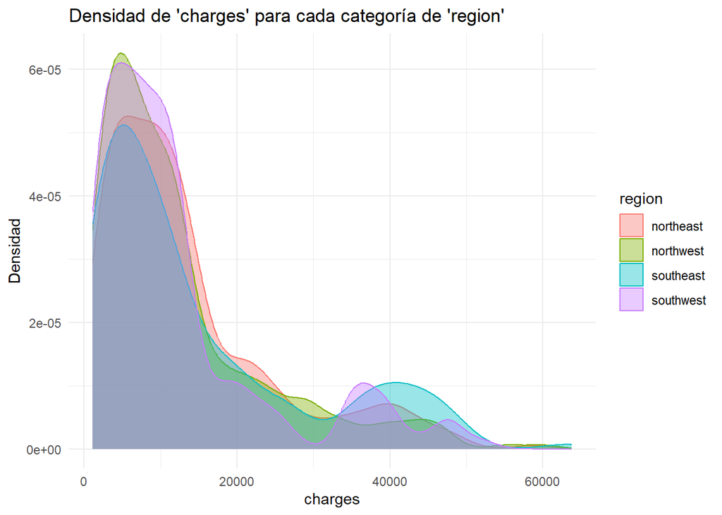

```r
datos |>
  ggplot(aes(x = charges, color = region, fill = region)) +
    geom_density(alpha = 0.4) +
    labs(
      title = "Densidad de 'charges' para cada categoría de 'region'",
      x = "charges",
      y = "Densidad"
    ) +
    theme_minimal()
```

En base a que aquellas funciones densidad no presentan una difencia resaltante, descartaremos la variable `region`. De esa manera, las variables cualitativas que emplearemos para esta investigación son solo `sex` y `smoker`.

Por otro lado, en el caso de las variables cuantitativas, primero inspeccionamos la correlación entre aquellas. Esto para descartar alguna de las variables que presente (de ser el caso) alta correlación lineal con otra variable cuantitativa.

A continuación, presentamos un heatmap de aquella matriz de correlaciones:

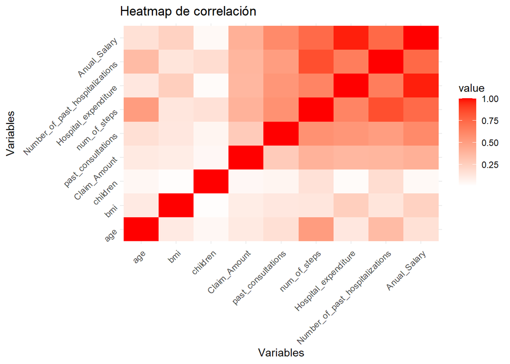

```r
datos_sin_na <- tidyr::drop_na(datos)

matriz_cor <- datos_sin_na |>
  dplyr::select(
    age,
    bmi,
    children,
    Claim_Amount,
    past_consultations,
    num_of_steps,
    Hospital_expenditure,
    Number_of_past_hospitalizations,
    Anual_Salary,
  ) |>
  cor()

melt(matriz_cor) |>
  ggplot(aes(Var1, Var2, fill = value)) +
    geom_tile() +
    scale_fill_gradient2(low = "blue", high = "red", mid = "white", midpoint = 0) +
    theme_minimal() +
    theme(
      axis.text.x = element_text(angle = 45, hjust = 1),
        axis.text.y = element_text(angle = 45, hjust = 1)
      ) +
    labs(title = "Heatmap de correlación", x = "Variables", y = "Variables")
```

Observamos una alta correlación entre `Anual_Salary` y `Hospital_expenditure`, con un valor de 0.9692177. Asimismo, como la variable de salario anual es más sencilla de recopilar (por ejemplo, en una encuesta) que la de gasto de hospital, descartamos la variable cuantitativa `Hospital_expenditure`.

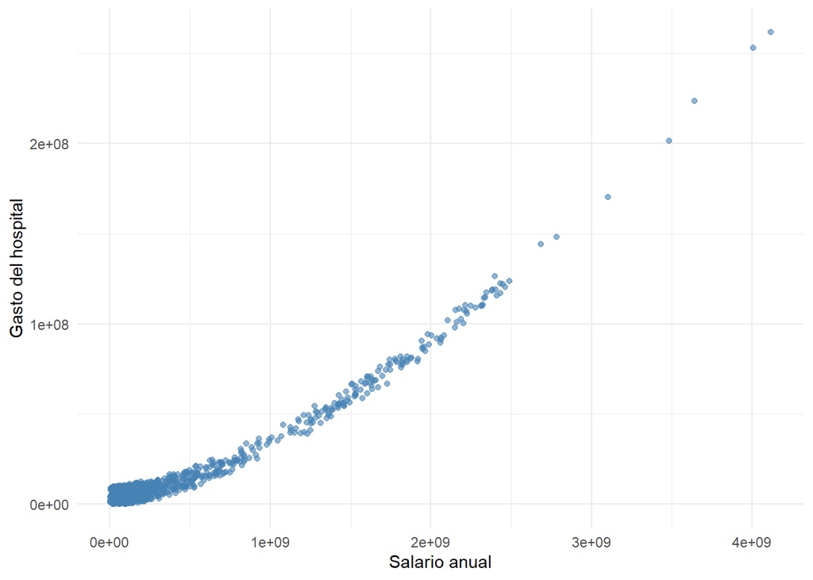

```r
datos |>
  ggplot(aes(x = Anual_Salary, y = Hospital_expenditure)) +
  geom_point(color = "steelblue", alpha = 0.6) +
  labs(x = "Salario anual", y = "Gasto del hospital") +
  theme_minimal()
```

#### Variable cuantitativa `num_of_steps`

Inicialmente se consideró descartar la variable referente al número de pasos que realizó el paciente en cierto día. Esto pues, a primera vista, no se esperaría que tal información resulte relevante para el costo final por el procedimiento médico.

Graficamos tal posible regreso contra la variable respuesta:

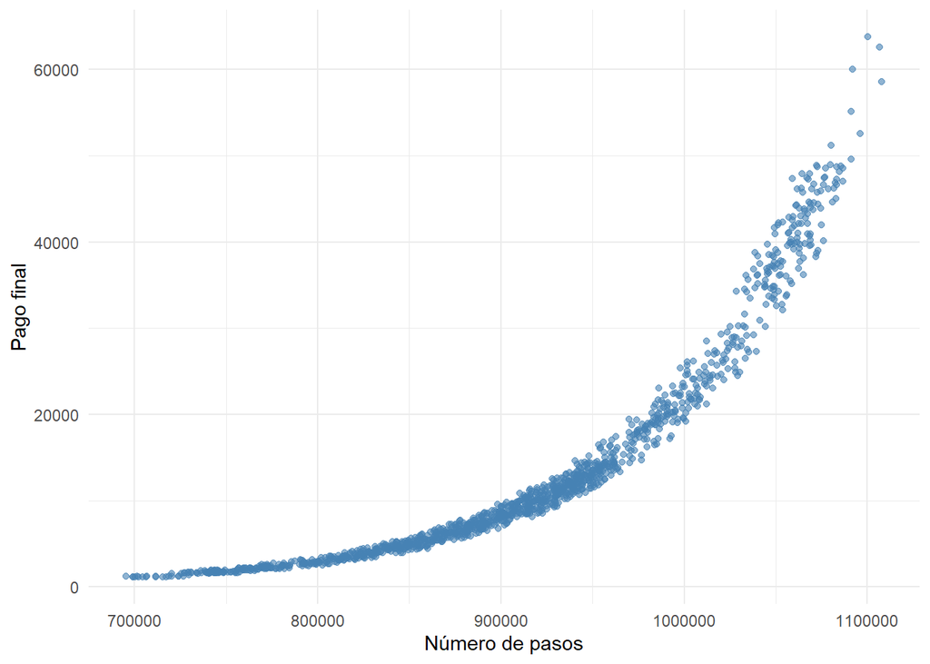

```r
datos |>
  ggplot(aes(x = num_of_steps, y = charges)) +
  geom_point(color = "steelblue", alpha = 0.6) +
  labs(x = "Número de pasos", y = "Pago final") +
  theme_minimal()
```

En base a que la relación parece asemejarse a una exponencial, graficamos la variable `num_of_steps` contra el logaritmo de la variable respuesta:

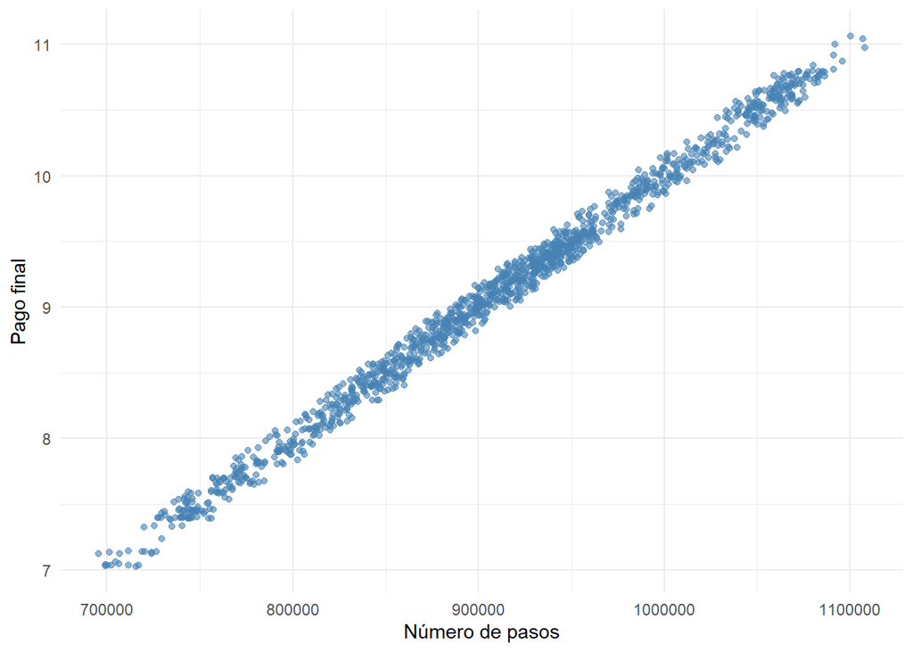

```r
datos |>
  dplyr::mutate(scaled_rsp = log(charges)) |>
  ggplot(aes(x = num_of_steps, y = scaled_rsp)) +
  geom_point(color = "steelblue", alpha = 0.6) +
  labs(x = "Número de pasos", y = "Pago final") +
  theme_minimal()
```

En base a que aquella relación parece ser *aproximadamente* lineal, optamos por no descartar la variable cuantitativa `num_of_steps`.

#### Variable cuantitativa `num_of_steps`

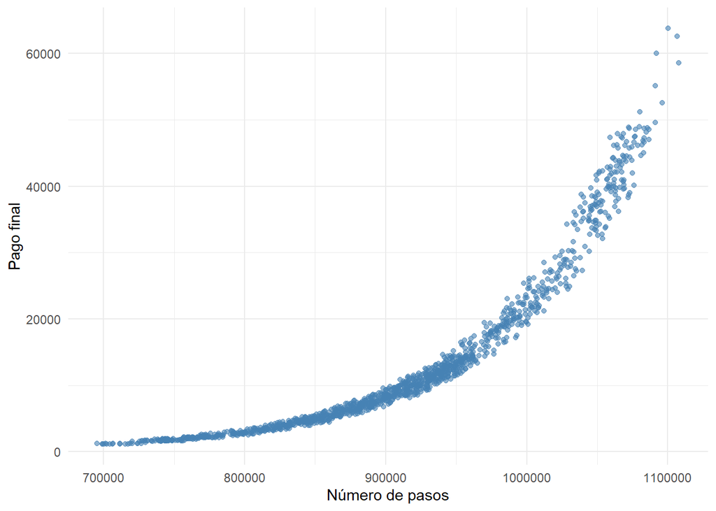

```r
datos |>
  ggplot(aes(x = num_of_steps, y = charges)) +
  geom_point(color = "steelblue", alpha = 0.6) +
  labs(x = "Número de pasos", y = "Pago final") +
  theme_minimal()
```

#### Variable cuantitativa `age`

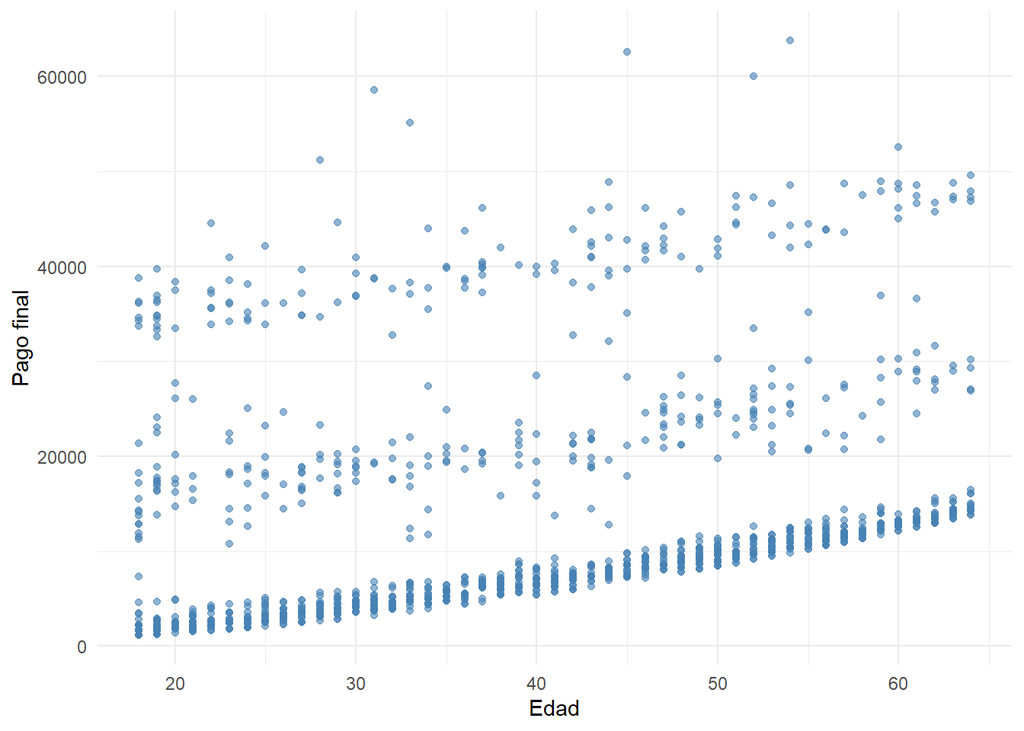

```r
datos |>
  ggplot(aes(x = age, y = charges)) +
  geom_point(color = "steelblue", alpha = 0.6) +
  labs(x = "Edad", y = "Pago final") +
  theme_minimal()
```

#### Variable cuantitativa `bmi`

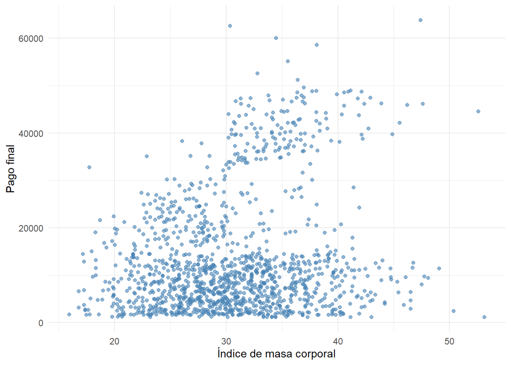

```r
datos |>
  ggplot(aes(x = bmi, y = charges)) +
  geom_point(color = "steelblue", alpha = 0.6) +
  labs(x = "Índice de masa corporal", y = "Pago final") +
  theme_minimal()
```

#### Variable cuantitativa `children`

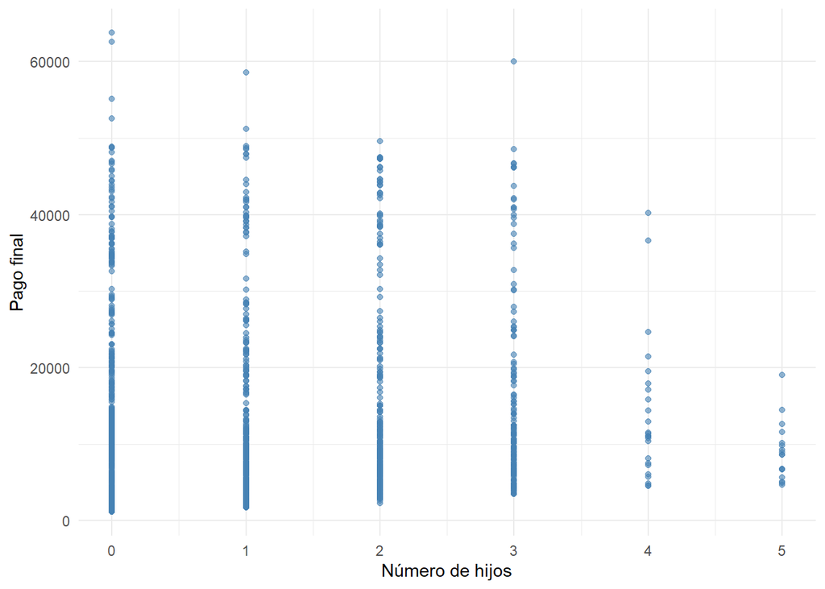

```r
datos |>
  ggplot(aes(x = children, y = charges)) +
  geom_point(color = "steelblue", alpha = 0.6) +
  labs(x = "Número de hijos", y = "Pago final") +
  theme_minimal()
```

#### Variable cuantitativa `past_consultations`

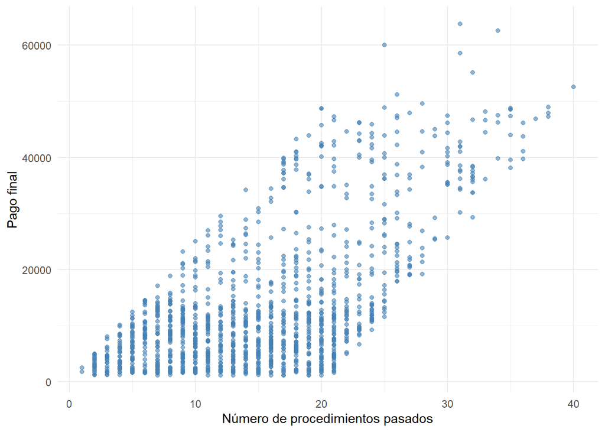

```r
datos |>
  ggplot(aes(x = past_consultations, y = charges)) +
  geom_point(color = "steelblue", alpha = 0.6) +
  labs(x = "Número de procedimientos pasados", y = "Pago final") +
  theme_minimal()
```

Descartamos la variable cuantitativa `children`, pues, en base a este simple análisis inicial, no parece indicar algún de tipo de relación lineal con la variable por predecir. Es más, su gráfico de dispersión parece sugerir que consideremos a la variable `children` como cualitativa.

### Variables finales

- Variables cualitativas:
  - `sex`
  - `smoker`
- Variables cuantitativas:
  - `age`
  - `bmi`
  - `Claim_Amount`
  - `past_consultations`
  - `num_of_steps`
  - `Number_of_past_hospitalizations`
  - `Anual_Salary`
  - `charges` (**variable respuesta**)

## Base de datos

La base de datos consiste de 1338 observaciones. Si eliminamos filas que posean algún dato vacío, se tienen 1287 observaciones.

Para limitarnos a 500 filas, realizaremos un muestreo:

```r
datos_finales <- datos_sin_na |>
  dplyr::select(
    sex,
    smoker,
    age,
    bmi,
    Claim_Amount,
    past_consultations,
    num_of_steps,
    Number_of_past_hospitalizations,
    Anual_Salary,
    charges
  )

datos_finales <- dplyr::sample_n(datos_finales, 500)

openxlsx::write.xlsx(datos_finales, 'datos.xlsx')
```